# Discussion 10 Solution

Huaiyu

11/19/2019

```r
library(rstan)
library(bayesplot)
library(rstanarm)
```

## Baysian Linear Regression

Today we see the example of wine quality with the help of rstan and rstanarm package. The goal is to model wine quality based on bayesian linear regression.

### 1. Data

```r
d <- read.delim("winequality-red.csv", sep = ";")
d <- d[!duplicated(d), ] # remove the duplicates
dim(d)
```

```
## [1] 1359   12
```

There are 11 predictors as “fixed.acidity”, “volatile.acidity”, “citric.acid” , “residual.sugar”, “chlorides”, “free.sulfur.dioxide” , “total.sulfur.dioxide”, “density”, “pH”, “sulphates” and “alcohol” while response is “quality”.

```r
names(d)
```

```
##  [1] "fixed.acidity"        "volatile.acidity"     "citric.acid"
##  [4] "residual.sugar"       "chlorides"            "free.sulfur.dioxide"
##  [7] "total.sulfur.dioxide" "density"              "pH"
## [10] "sulphates"            "alcohol"              "quality"
```

Before writing stan file, we need to set up dataset as below.

```r
ds <- as.data.frame(scale(d))
y <- ds$quality
X <- as.matrix(ds[, 1:11])
stan_data <- list(X = X, K = ncol(X), N = nrow(ds), y = y)
```

### 2. Bayesian Linear Model

Assume data $y \sim N(\alpha + \beta X, \sigma^2)$ with prior $\alpha \sim N(0, 10^2)$, $\beta \sim N(0, 10^2)$ and $\sigma \sim Cauchy(0, 2.5)$. Please write stan file and name it as linear_model.stan.

And then fit your stan model with iteration 1000 times and 4 chains.

```r
stan_model <- "~/Documents/BU_2019_Fall/linear_model.stan"
fit <- stan(file = stan_model, data = stan_data, iter = 1000, chains = 4)
```

```r
print(fit)
```

[output not shown]

```r
posterior <- extract(fit, permuted = FALSE)
mcmc_areas(
  posterior,
  pars = c(paste0("beta[",1:11,"]")),
  prob = 0.8, # 80% intervals
  prob_outer = 0.99, # 99%
  point_est = "mean"
)
```

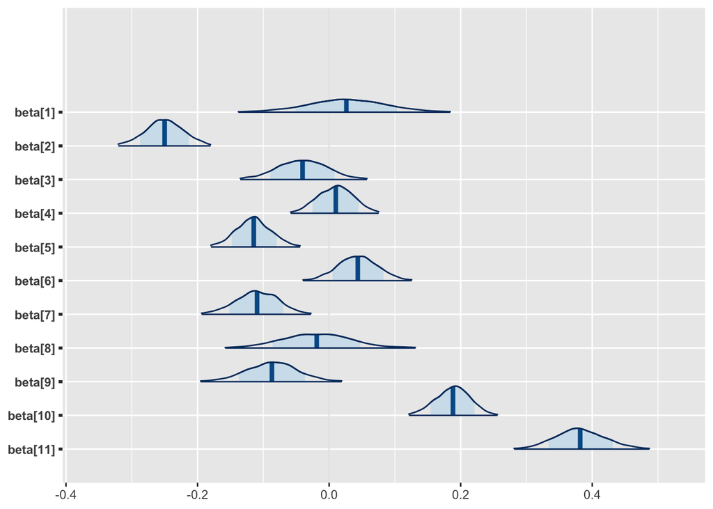

### 3. Posterior Predictive Model Checking

Compare density and empirical cdf of y repicates with observations y, then have a look at intervals. Is this a good model?

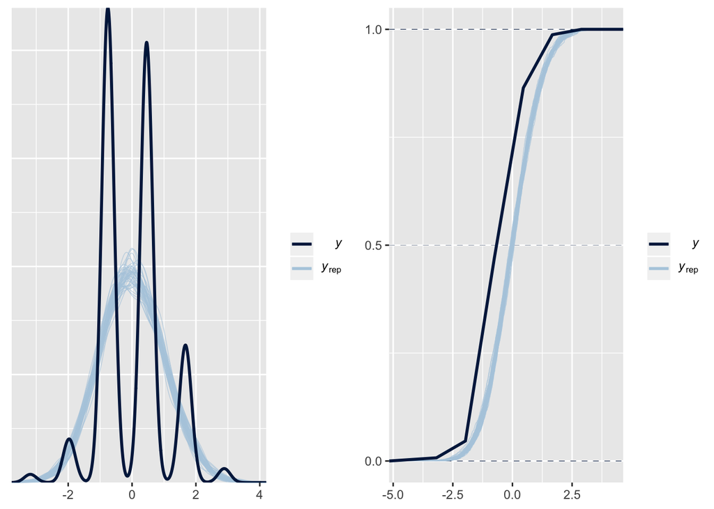

```r
posterior <- extract(fit)
yrep <- posterior$y_rep
p1 <- ppc_dens_overlay(y, yrep[sample(nrow(yrep), 50), ])
p2 <- ppc_ecdf_overlay(y, yrep[sample(nrow(yrep), 50), ])
cowplot::plot_grid(p1, p2)
```

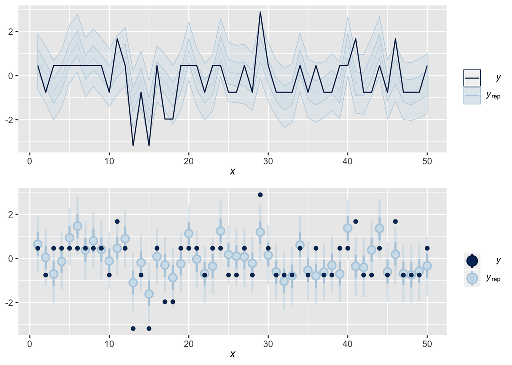

```r
i <- sample(length(y), 50);
p1 <- ppc_ribbon(y[i], yrep[, i]); p2_1i <- ppc_intervals(y[i], yrep[, i])
cowplot::plot_grid(p1, p2_1i, ncol = 1)
```

```r
summary(lm(y ~ X))
```

```
##
## Call:
## lm(formula = y ~ X)
##
## Residuals:
##     Min      1Q  Median      3Q     Max
## -3.2166 -0.4403 -0.0466  0.5611  2.4243
##
## Coefficients:
##                         Estimate Std. Error t value Pr(>|t|)
## (Intercept)            6.111e-16  2.172e-02   0.000 1.000000
## Xfixed.acidity         2.650e-02  6.101e-02   0.434 0.664067
## Xvolatile.acidity     -2.490e-01  2.898e-02  -8.593  < 2e-16 ***
## Xcitric.acid          -3.899e-02  3.842e-02  -1.015 0.310259
## Xresidual.sugar        1.167e-02  2.785e-02   0.419 0.675207
## Xchlorides            -1.157e-01  2.689e-02  -4.304 1.80e-05 ***
## Xfree.sulfur.dioxide   4.241e-02  3.036e-02   1.397 0.162645
## Xtotal.sulfur.dioxide -1.098e-01  3.236e-02  -3.394 0.000709 ***
## Xdensity              -2.040e-02  5.447e-02  -0.375 0.708036
## XpH                   -8.631e-02  4.006e-02  -2.155 0.031369 *
## Xsulphates             1.896e-01  2.632e-02   7.202 9.87e-13 ***
## Xalcohol               3.804e-01  3.852e-02   9.876  < 2e-16 ***
## ---
## Signif. codes:  0 '***' 0.001 '**' 0.01 '*' 0.05 '.' 0.1 ' ' 1
##
## Residual standard error: 0.8009 on 1347 degrees of freedom
## Multiple R-squared:  0.3638, Adjusted R-squared:  0.3586
## F-statistic: 70.02 on 11 and 1347 DF,  p-value: < 2.2e-16
```

You can use some techniques from linear model class, such as feature selection with AIC/BIC, detect whether correlation exists between independent variables, add polynomial terms and so on.

#### 4. Rstanarm Package

In the rstanarm package, the prior must be a call to $R^2$ with its location argument specified or NULL, which would indicate a standard uniform prior for the $R^2$. The choice of prior here is based on design matrix, and more details are here: https://cran.r-project.org/web/packages/rstanarm/vignettes/lm.html.

If you want to specify any of the other types of priors, you’ll need to switch to stan_glm. With the default family (gaussian), it will be equivalent to stan_lm. This runs faster than rstan package, and you don’t need to write anything about stan file.

```r
post <-
  stan_lm(y ~ X, data = ds, prior = R2(location = 0.5), iter = 1000, chains = 4)
```

```r
post
```

```
## stan_lm
##  family:       gaussian [identity]
##  formula:      y ~ X
##  observations: 1359
##  predictors:   12
## ------
##                       Median MAD_SD
## (Intercept)            0.0    0.0
## Xfixed.acidity         0.0    0.1
## Xvolatile.acidity     -0.2    0.0
## Xcitric.acid           0.0    0.0
## Xresidual.sugar        0.0    0.0
## Xchlorides            -0.1    0.0
## Xfree.sulfur.dioxide   0.0    0.0
## Xtotal.sulfur.dioxide -0.1    0.0
## Xdensity               0.0    0.1
## XpH                   -0.1    0.0
## Xsulphates             0.2    0.0
## Xalcohol               0.4    0.0
##
## Auxiliary parameter(s):
##               Median MAD_SD
## R2            0.4    0.0
## log-fit_ratio 0.0    0.0
## sigma         0.8    0.0
##
## ------
## * For help interpreting the printed output see ?print.stanreg
## * For info on the priors used see ?prior_summary.stanreg
```

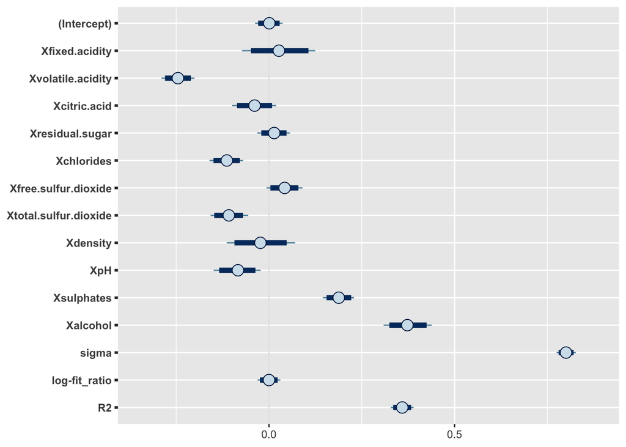

```r
plot(post, prob = 0.8)
```

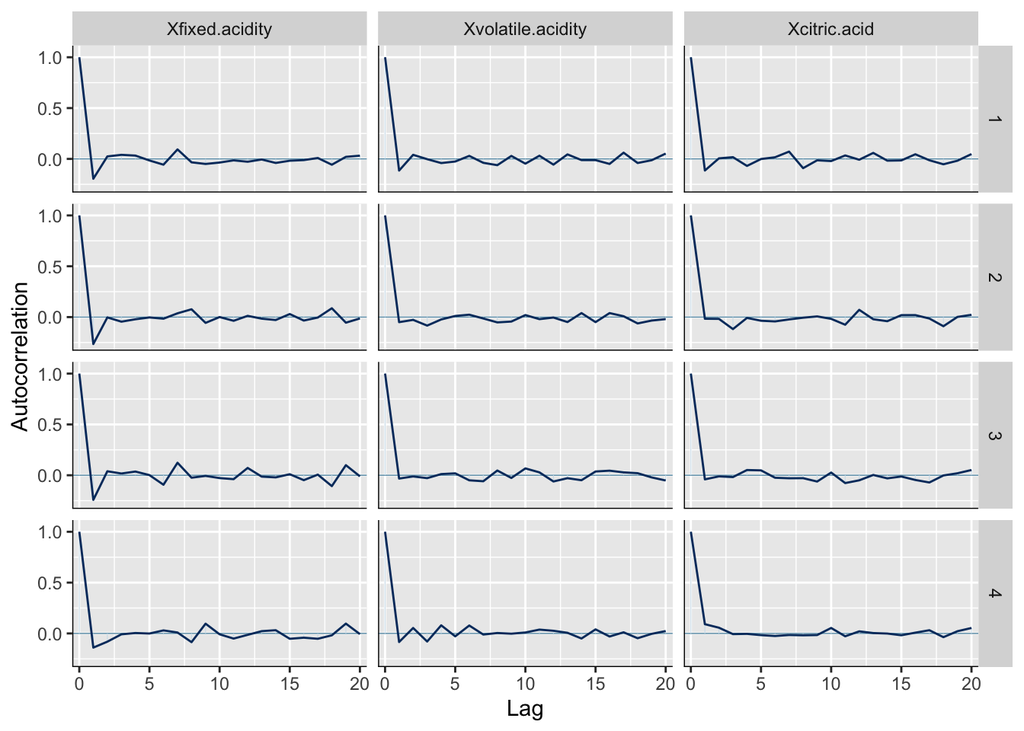

```r
plot(post, plotfun = "acf", par = c("Xfixed.acidity", "Xvolatile.acidity", "Xcitric.acid"))
```

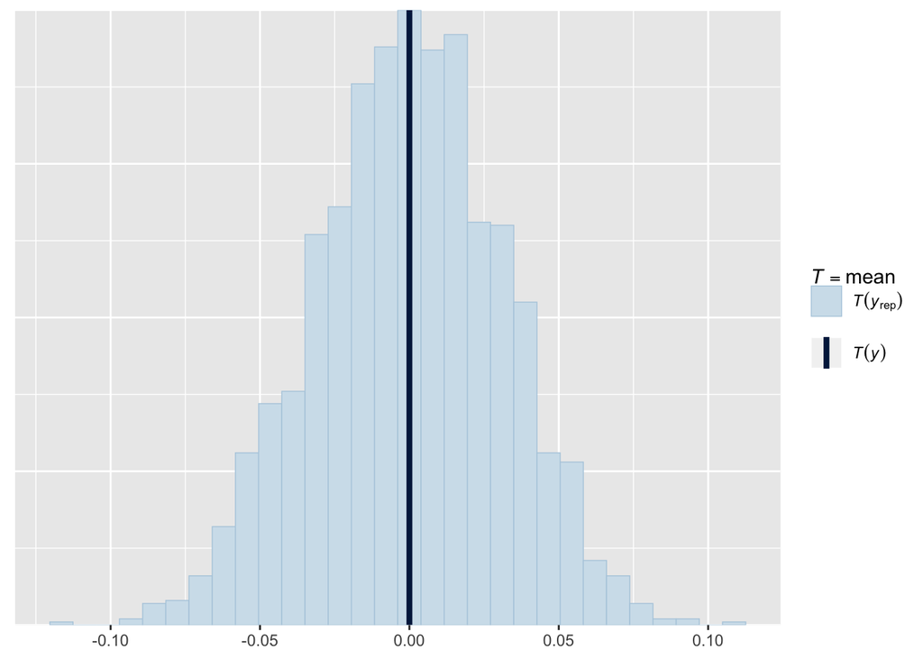

```r
pp_check(post, plotfun = "stat", stat = "mean")
```

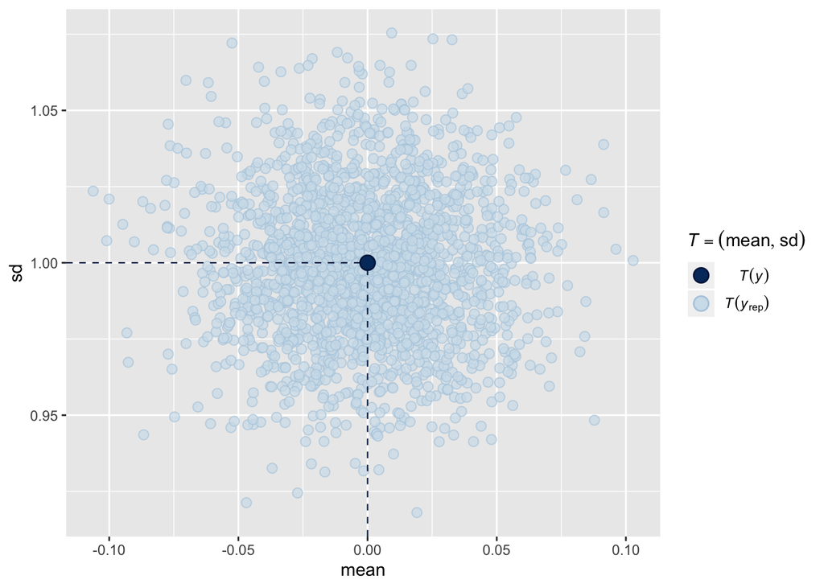

```r
pp_check(post, plotfun = "stat_2d", stat = c("mean", "sd"))
```

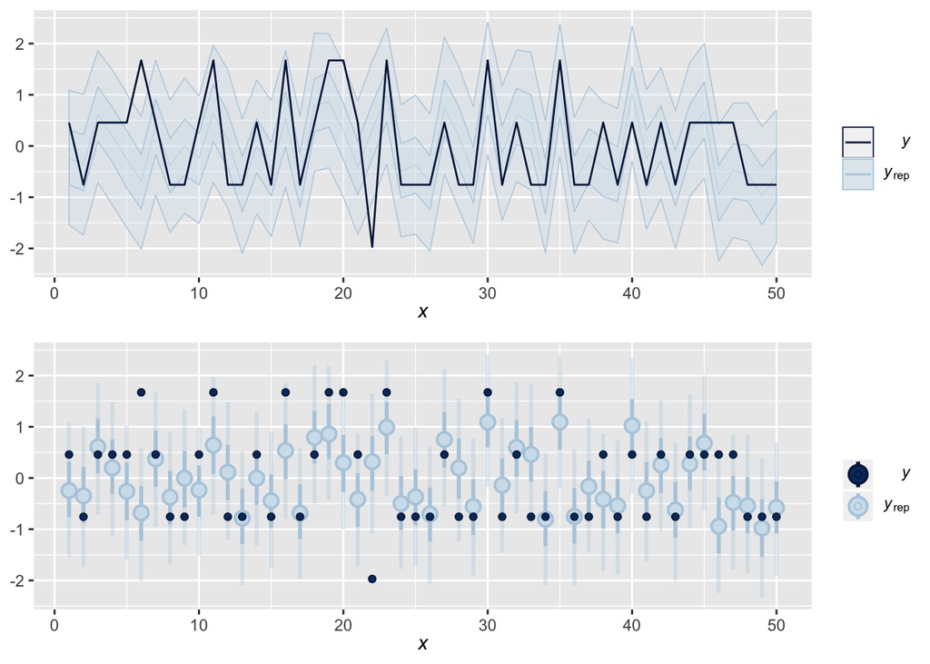

```r
yrep2 <- posterior_predict(post, newdata = ds)
i <- sample(length(y), 50);
p1 <- ppc_ribbon(y[i], yrep2[, i]); p2_1i <- ppc_intervals(y[i], yrep2[, i])
cowplot::plot_grid(p1, p2_1i, ncol = 1)
```

In the later lecture, you can also use rstanarm package when analyzing generlized linear model (GLM).

There will be no discussion next week. Happy Thanksgiving Day!